# Machine Learning in Python: Exploring Table Data

### Malgorzata Z. Makos, Richa Mahajan, Farbod Tavakoli Khomeini

## A. Business Understanding

The dataset selected to perform this analysis presents the data based on certain driving behavior. The data was collected using a smartphone while driving. The raw data was translated into the Earth coordinate system because the smartphone and the car may have different coordinate systems. The smartphone was held in the same direction during the ride. Later the mathematical features were extracted such as mean, variance, skewness, kurtosis, median, min, max, quantile 10 to 90, and coefficient of variation, leading to the prediction and evaluation of various traffic and driving behaviors. The data was collected by Farbod about one and a half year ago with his own car using Sensor-Recorder application which is suitable for saving the data of sensors such as acceleration, gyroscope, proximity, gravity, and linear acceleration in the smartphone.

Predicting whether the driver has a tendency to drive aggressively or non-aggressively is the main task of this data. This data is of wide interest to insurance companies, police, and city governments. Predicting whether the driving is aggressive or not, from the data which is taken while driving can be useful to regulate the cost of insurance, produce a safety index, or even reduce the fuel consumption. For this prediction task to be considered useful to these third parties, like police, the accuracy should be as good as it can be, preferably better than 85% as it will be used to predict the fault of respective drivers involved in the accident and will affect people who are involved in these accidents. In the case where Insurance companies are using this algorithm, our prediction task should have at least 90% accuracy as it will affect the cost of the insurance for the customers of insurance companies.

There are different movement categories, which are described as acceleration, brake, speed bumper, turn, lane changing and background. Having the coordinate of the car to be driven aligned with the Y-axis, the acceleration, brake, speed bumper are mostly affected by mean and variance of X- and Y-axis of the acceleration, while the turns and the lane changing are mostly affected by the mean and variance of X- and Z- axis of the gyroscope.

Another important issue is about the type of behavior of each movement: aggressive or non-aggressive. To be more specific, aggressive or nonaggressive driving behavior is highly dependent on the driving style and it's not logical to assume a constant amount for a variable such as acceleration to label it as aggressive or nonaggressive but in general, there are some conditions that cause aggressiveness such as when one drives at 100 km/h speed and immediately stops the car so this action results in aggressive brake.

## B. Data Understanding

The libraries have been imported and their version printed below.

```python
import pandas as pd
import matplotlib
import matplotlib.pyplot as plt
import seaborn as sns
import numpy as np
import numpy.random as nr
import math
from sklearn import preprocessing
import sklearn.model_selection as ms
from sklearn import linear_model
import sklearn.metrics as sklm
from sklearn.manifold import TSNE

# Hide warnings
import warnings
warnings.filterwarnings("ignore")

%matplotlib inline

print('Pandas:', pd.__version__)
print('Numpy:',np.__version__)
print('Seaborn:', sns. __version__)
print('Matplotlib:', matplotlib. __version__)
```

```
Pandas: 0.24.2
Numpy: 1.16.4
Seaborn: 0.9.0
Matplotlib: 3.1.0
```

```python
df = pd.read_csv('10ms.csv')
df.head()
```

|  | MeanAccX | VarAccX | KurtosisAccX | SkewnessAccX | MaxAccX | MinAccX | COVAccX | MedianAccX | Perc10Accx | Perc20AccX | ... | Perc20RVCos | Perc30RVCos | Perc40RVCos | Perc50RVCos | Perc60RVCos | Perc70RVCos | Perc80RVCos | Perc90RVCos | Duration | Movement |
| --- | --- | --- | --- | --- | --- | --- | --- | --- | --- | --- | --- | --- | --- | --- | --- | --- | --- | --- | --- | --- | --- |
| 0 | -0.35321 | 0.080529 | 2.9402 | -0.18151 | 0.5375 | -1.1437 | -0.80342 | -0.32777 | -0.7478 | -0.59958 | ... | 0.92994 | 0.9325 | 0.93522 | 0.9362 | 0.93765 | 0.9427 | 0.95544 | 0.96404 | 13510 | Acceleration-Ag |
| 1 | 0.024834 | 0.64268 | 7.2583 | 0.29106 | 4.3524 | -3.4927 | 32.281 | 0.011013 | -0.87484 | -0.5341 | ... | 0.3465 | 0.35064 | 0.36129 | 0.36963 | 0.37336 | 0.37683 | 0.38239 | 0.3858 | 11720 | Acceleration-Ag |
| 2 | 0.39079 | 1.1348 | 4.3842 | 0.79201 | 3.9679 | -2.7991 | 2.7259 | 0.24038 | -0.6924 | -0.43754 | ... | 0.55825 | 0.56681 | 0.57406 | 0.58034 | 0.58141 | 0.59287 | 0.59998 | 0.60956 | 7470 | Acceleration-Ag |
| 3 | -0.029753 | 0.90238 | 4.9214 | 0.20249 | 4.0527 | -3.1778 | -31.927 | -0.03292 | -1.1128 | -0.73837 | ... | 0.49985 | 0.50297 | 0.50697 | 0.51107 | 0.51709 | 0.52138 | 0.5339 | 0.55766 | 9340 | Acceleration-Ag |
| 4 | -0.26071 | 0.065455 | 4.7721 | 0.74965 | 0.9268 | -0.92392 | -0.98132 | -0.27342 | -0.58586 | -0.44748 | ... | 0.58794 | 0.58954 | 0.59061 | 0.59325 | 0.59448 | 0.59564 | 0.59637 | 0.59644 | 9860 | Acceleration-Ag |

5 rows × 274 columns

```python
df.shape
```

```
(4114, 274)
```

```python
df.describe()
```

|  | Duration |
| --- | --- |
| count | 4114.000000 |
| mean | 6186.679631 |
| std | 2999.341890 |
| min | 10.000000 |
| 25% | 4070.000000 |
| 50% | 5650.500000 |
| 75% | 7940.750000 |
| max | 47508.000000 |

The choosen columns for the further analysis are as follow: 'MeanAccX', 'MeanAccY', 'VarAccX', 'VarAccY', 'MeanGyrX', 'MeanGyrZ', 'VarGyrX', 'VarGyrZ'

The MeanAccX, MeanAccY, VarAccX, VarAccY are appropriate for recognizing pedal movements such as acceleration and braking. While MeanGyrX, MeanGyrZ, VarGyrX, and VarGyrZ are suitable for detecting the steering movements such as lane changing, turn, and bumper.

```python
cols = ['MeanAccX', 'MeanAccY', 'VarAccX', 'VarAccY', 'MeanGyrX', 'MeanGyrZ', 'VarGyrX', 'VarGyrZ']
```

There is some missing data in the database due to errors or bugs on the smartphone or GPS. The missing values in the dataset are presented as '?'. The code below identifies the columns with missing values and also displays the counts of missing values.

```python
# identify the columns with missing values
(df[cols].astype(np.object) == '?').any()
```

```
MeanAccX    True
MeanAccY    True
VarAccX     True
VarAccY     True
MeanGyrX    True
MeanGyrZ    True
VarGyrX     True
VarGyrZ     True
dtype: bool
```

```python
#displays the counts of missing values
for col in cols:
    if df[col].dtype == object:
        count = 0
        count = [count + 1 for x in df[col] if x == '?']
        print(col + ' ' + str(sum(count)))
```

```
MeanAccX 63
MeanAccY 63
VarAccX 65
VarAccY 65
MeanGyrX 118
MeanGyrZ 118
VarGyrX 120
VarGyrZ 120
```

In the cell below, we remove all of the rows with missing data. As mentioned before, the data were collected during the car driving in different conditions. Missing data due to lack of GPS connection or other technical problems are not possible to replace, and therefore it is best to remove the rows with missing values as we have good amount of data and deleting some of the instances will not affect our predication task considerably.

```python
# Remove rows with missing values
cols = ['MeanAccX', 'MeanAccY', 'VarAccX', 'VarAccY', 'MeanGyrX', 'MeanGyrZ', 'VarGyrX', 'VarGyrZ']
for column in cols:
    df.loc[df[column] == '?', column] = np.nan
df.dropna(axis = 0, inplace = True)
df.shape
```

```
(3931, 274)
```

```python
# display data types of each column
df[cols].dtypes
```

```
MeanAccX    object
MeanAccY    object
VarAccX     object
VarAccY     object
MeanGyrX    object
MeanGyrZ    object
VarGyrX     object
VarGyrZ     object
dtype: object
```

```python
# transform data
column = ['MeanAccX', 'MeanAccY', 'VarAccX', 'VarAccY', 'MeanGyrX', 'MeanGyrZ', 'VarGyrX', 'VarGyrZ']
for column in cols:
    df[column] = pd.to_numeric(df[column])
df[cols].dtypes
```

```
MeanAccX    float64
MeanAccY    float64
VarAccX     float64
VarAccY     float64
MeanGyrX    float64
MeanGyrZ    float64
VarGyrX     float64
VarGyrZ     float64
dtype: object
```

```python
df['Movement'].dtype
```

```
dtype('O')
```

As seen in the above two cells, the data type of the attributes we are considering in our algorithm is an object. We transform this data into float64 since all the considered attributes are numeric floating-point. One other attribute we will consider in this algorithm is 'Movement'. It contains the information about kind of movements like turns,brakes,lane changes,etc for the specific instances of the data. It also has two subsets of these movements in it, which are aggressive and non-aggressive. We do not change the data type of this attribute as the data in it is not numeric and has strings. We keep it as the object in the dataset. Also, for better classification, we have taken the subset of 'Movement' attribute which had aggressive and non-aggressive as the category of different movements and added an additional column presenting aggressive (1) and nonaggressive (0) driving for each type of movement.

```python
# add col for aggresive (1) and non-aggresive (0) driving behavior
l = []
for i in df.Movement:
    if 'Ag' in i:
        l.append(1)
    else:
        l.append(0)
df['Ag_Non'] = np.array(l)
df.head()
```

|  | MeanAccX | VarAccX | KurtosisAccX | SkewnessAccX | MaxAccX | MinAccX | COVAccX | MedianAccX | Perc10Accx | Perc20AccX | ... | Perc30RVCos | Perc40RVCos | Perc50RVCos | Perc60RVCos | Perc70RVCos | Perc80RVCos | Perc90RVCos | Duration | Movement | Ag_Non |
| --- | --- | --- | --- | --- | --- | --- | --- | --- | --- | --- | --- | --- | --- | --- | --- | --- | --- | --- | --- | --- | --- |
| 0 | -0.353210 | 0.080529 | 2.9402 | -0.18151 | 0.5375 | -1.1437 | -0.80342 | -0.32777 | -0.7478 | -0.59958 | ... | 0.9325 | 0.93522 | 0.9362 | 0.93765 | 0.9427 | 0.95544 | 0.96404 | 13510 | Acceleration-Ag | 1 |
| 1 | 0.024834 | 0.642680 | 7.2583 | 0.29106 | 4.3524 | -3.4927 | 32.281 | 0.011013 | -0.87484 | -0.5341 | ... | 0.35064 | 0.36129 | 0.36963 | 0.37336 | 0.37683 | 0.38239 | 0.3858 | 11720 | Acceleration-Ag | 1 |
| 2 | 0.390790 | 1.134800 | 4.3842 | 0.79201 | 3.9679 | -2.7991 | 2.7259 | 0.24038 | -0.6924 | -0.43754 | ... | 0.56681 | 0.57406 | 0.58034 | 0.58141 | 0.59287 | 0.59998 | 0.60956 | 7470 | Acceleration-Ag | 1 |
| 3 | -0.029753 | 0.902380 | 4.9214 | 0.20249 | 4.0527 | -3.1778 | -31.927 | -0.03292 | -1.1128 | -0.73837 | ... | 0.50297 | 0.50697 | 0.51107 | 0.51709 | 0.52138 | 0.5339 | 0.55766 | 9340 | Acceleration-Ag | 1 |
| 4 | -0.260710 | 0.065455 | 4.7721 | 0.74965 | 0.9268 | -0.92392 | -0.98132 | -0.27342 | -0.58586 | -0.44748 | ... | 0.58954 | 0.59061 | 0.59325 | 0.59448 | 0.59564 | 0.59637 | 0.59644 | 9860 | Acceleration-Ag | 1 |

5 rows × 275 columns

```python
print (df[cols].info())
```

```
<class 'pandas.core.frame.DataFrame'>
Int64Index: 3931 entries, 0 to 4113
Data columns (total 8 columns):
MeanAccX    3931 non-null float64
MeanAccY    3931 non-null float64
VarAccX     3931 non-null float64
VarAccY     3931 non-null float64
MeanGyrX    3931 non-null float64
MeanGyrZ    3931 non-null float64
VarGyrX     3931 non-null float64
VarGyrZ     3931 non-null float64
dtypes: float64(8)
memory usage: 276.4 KB
None
```

# C. Data Vizualization

The amount of each movement and its category is presented below. Every single data for one of the aggressive acceleration results from a different trip using a car. Besides, the background data means that the driver had driven on a highway with a constant speed, and also without any special movement such as turn, braking, acceleration, lane changing, and bumper.

```python
df['Movement'].value_counts()
```

```
Turn-Ag             657
Turn-Non            624
LaneChanging-Ag     357
BackGround          331
LaneChanging-Non    320
Brake-Ag            318
Acceleration-Ag     293
Acceleration-Non    274
Bumper-Non          272
Bumper-Ag           266
Brake-Non           219
Name: Movement, dtype: int64
```

```python
df['Ag_Non'].value_counts()
```

```
0    2040
1    1891
Name: Ag_Non, dtype: int64
```

### Bar Plots

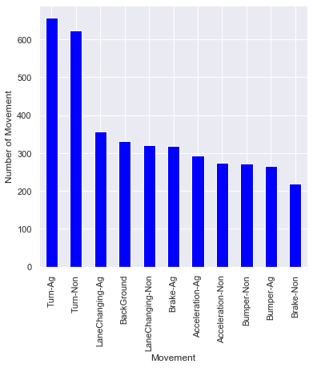

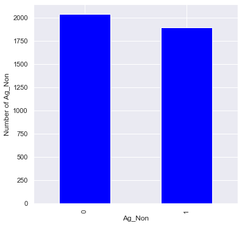

```python
# counts muber of movements
cols = ['MeanAccX', 'MeanAccY', 'VarAccX', 'VarAccY', 'MeanGyrX', 'MeanGyrZ', 'VarGyrX', 'VarGyrZ']
def plot_bars(df, cols):
    for col in cols:
        fig = plt.figure(figsize=(6,6))
        ax = fig.gca()
        counts = df[col].value_counts()
        counts.plot.bar(ax = ax, color = 'blue')
        ax.set_xlabel(col)
        ax.set_ylabel('Number of ' + col )
        plt.show()

plot_cols = ['Movement', 'Ag_Non']
plot_bars(df, plot_cols)
```

Above two visualizations are for the types of movements which are considered in the driving dataset. The first plot shows the total number of each type of movement. As seen clearly, the dataset contains a lot of readings taken for turns, the highest number of data collected is for aggressive turns and the lowest number of data is collected for non-aggressive braking. The second plot shows the total number of all types of movements for an aggressive and non-aggressive category. We can see that readings taken while driving non-aggressively are higher than readings taken for aggressive driving.

### Matrix plot

The following matrix plot shows the correlation between the features. The relationship level is indicated with colors and numbers where the lighter color, the better correlation is presented. As we can observe, there is very less correlation between the features. The matrix plot does not show any number over 0.4 (orange color). The lowest correlation, -0.52 (black color), is shown between MeanAccX and MeanGyrZ. The lack of correlation is a consequence of different sensors in smartphones for collecting data such as Gyroscope and Acceleration. The Gyroscope collects the rotational velocity of the car in each direction separately and the Acceleration collects the change in speed per second in each direction. Assuming the condition of the two sensors mentioned above, it is somehow illogical to relate these two features with each other because they are working separately. This is exactly what this correlation matrix plot shows us, that the features do not have much correlation between them.

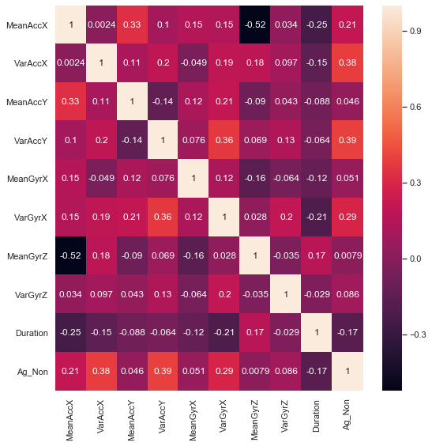

```python
cmap = sns.set(style="darkgrid") # one of the many styles to plot using

f, ax = plt.subplots(figsize=(8, 8))
sns.heatmap(df.corr(), cmap=cmap, annot=True)

f.tight_layout()
```

### Distributions

In the following section, the data was visualized using histograms and KDE. In the first plot, MeanAccX has values in the range of (-5.0,4.0), the most frequent data are in the range of (-1,1). This shows that the X-axis is taken into account just during the turns, or lane changing. On the other hand, the second plot MeanAccY shows the values in the range of (-3.0,8.0), where the positive values are in the majority. This is correlated with the Y-axis which displays straight movements.

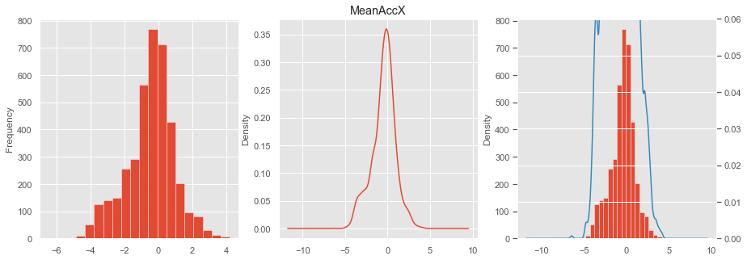

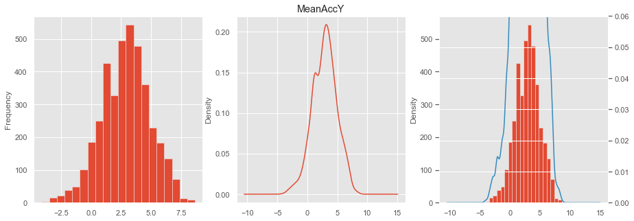

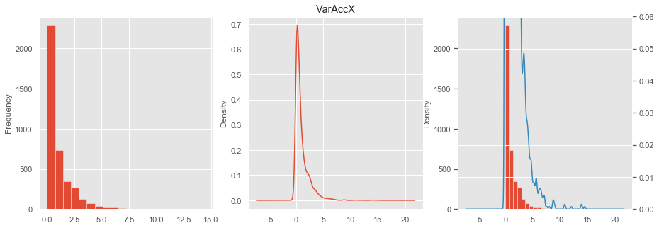

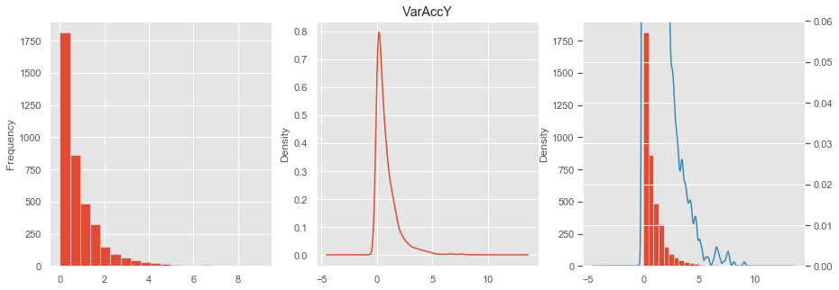

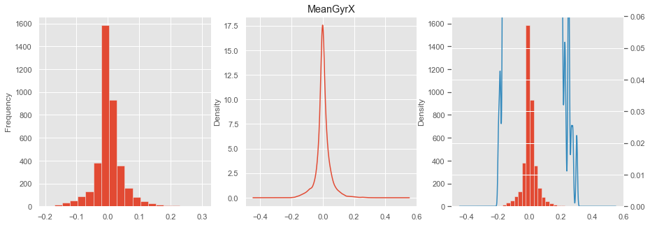

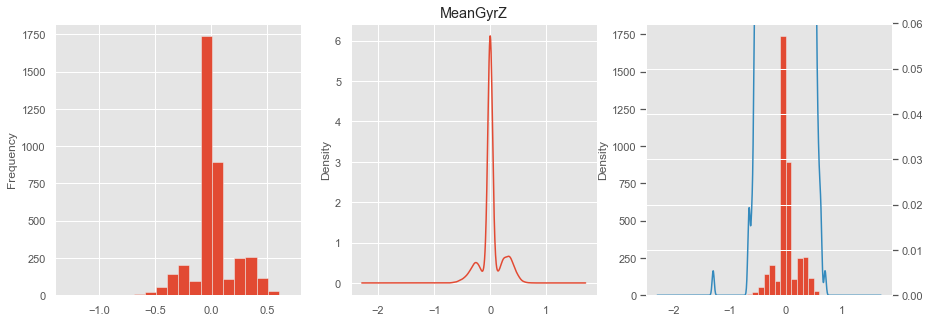

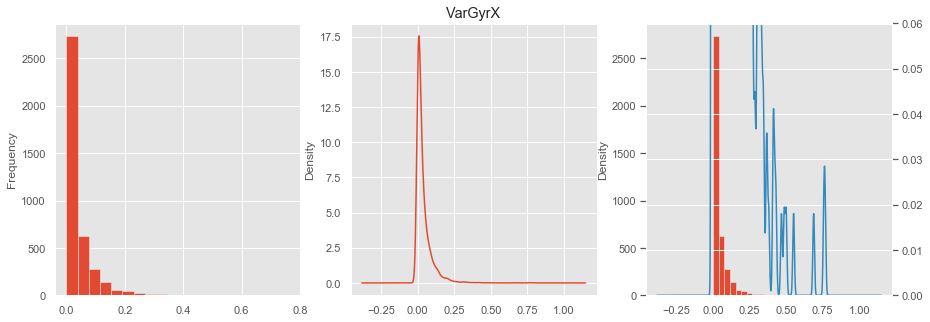

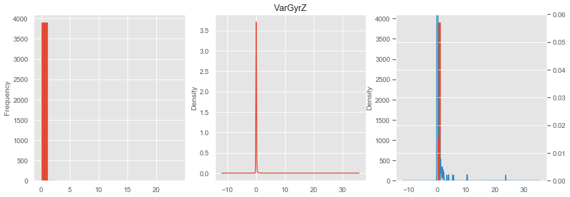

```python
column = ['MeanAccX', 'MeanAccY', 'VarAccX', 'VarAccY', 'MeanGyrX', 'MeanGyrZ', 'VarGyrX', 'VarGyrZ']
for col in column:
    plt.style.use('ggplot')
    fig = plt.figure(figsize=(15,5))

    plt.subplot(1,3,1)
    df[col].plot.hist(bins=20)

    plt.subplot(1,3,2)
    df[col].plot.kde(bw_method=0.2)
    plt.title(col)

    plt.subplot(1,3,3)
    df[col].plot.hist(bins=20)
    df[col].plot.kde(bw_method=0.1, secondary_y=True)
    plt.ylim([0, 0.06])

plt.show()
```

### Histograms

Also, as seen in the 3rd plot, which is 'VarAccX', the aggressive driving values completely overlap the data values for non-aggressive driving. This is interesting as it shows us that a value of 1 for 'VarAccX' doesn't necessarily mean that the driver was driving aggressively because the same value shows us that the driving was non-aggressive as there is an overlap. Such readings visualizations are very helpful for predictions in cases which are borderline.

In the case of 6th plot of 'MeanGyrZ', it is seen that the there is an overlap in the values of aggressive and non-aggressive values in the center, but there is no overlap for values near the two edges. so, the values in the range -0.70 to -0.40 and 0.45 to 0.70 would be considered aggressive and those in between would be non-aggressive.

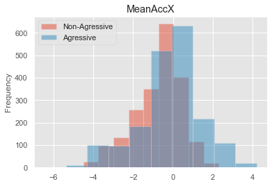

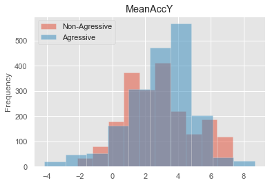

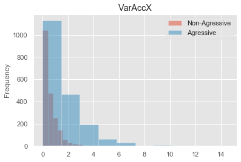

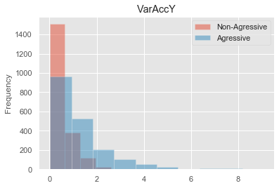

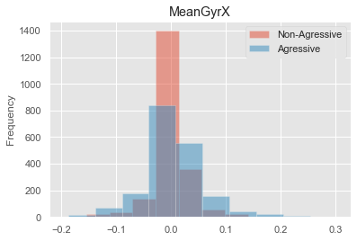

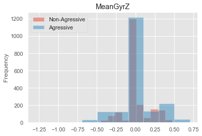

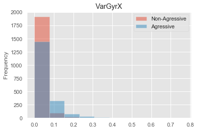

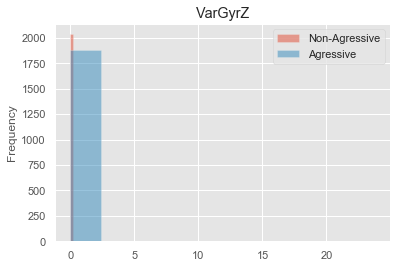

```python
column = ['MeanAccX', 'MeanAccY', 'VarAccX', 'VarAccY', 'MeanGyrX', 'MeanGyrZ', 'VarGyrX', 'VarGyrZ']
for col in column:
    plt.style.use('ggplot')
    df[col].groupby(df.Ag_Non).hist(alpha=0.5)
    labels= ["Non-Agressive","Agressive"]
    plt.legend(labels)
    plt.title(col)
    plt.ylabel('Frequency')
    plt.show()
```

### Scatter matrix

The scatter plot presents the relationship between the features with the distinguish for non-aggressive (O, red color) and aggressive (1, blue color) driving behavior. As a dimension, KDE is used for better visualization. The relationship between categories can not be clearly shown as it was described with the matrix plot. However, we can see that non- and aggressive variables overlap with each other.

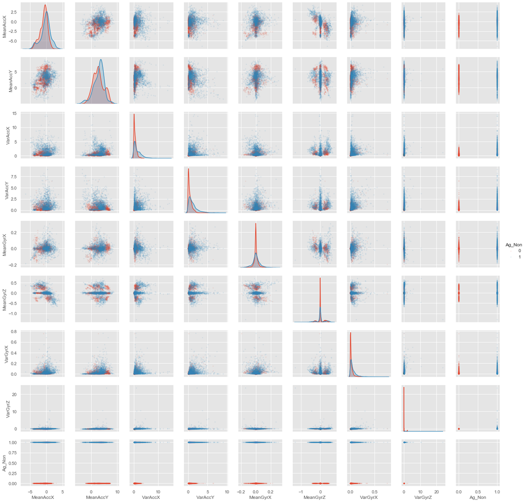

```python
df_jitter = df[['MeanAccX', 'MeanAccY', 'VarAccX', 'VarAccY', 'MeanGyrX', 'MeanGyrZ', 'VarGyrX', 'VarGyrZ','Ag_Non']]
sns.pairplot(df_jitter, hue = "Ag_Non", size=2, diag_kind="kde", plot_kws=dict(s=10, alpha=0.1, linewidth=0))
plt.show()
```

### Box Plots

We are visualizing the distribution for subsets of the 'Movement' attribute. Some of the subsets are Acceleration, Brake, Turn, Lane Changing, etc.

The following box plots show the relationship between the categorical variable of the 'Movement' column and numerical variables of the features.

For each categorical variable, a box plot is created for each of the features. In some of these cases, there are some noticeable differences between the variables and category. For example, in the MeanAccX the mean values of the first two categories are the same, while for MeanAccY they are different. Also, there is very less outliner in the MeanAccY plot, when compared to other plots.

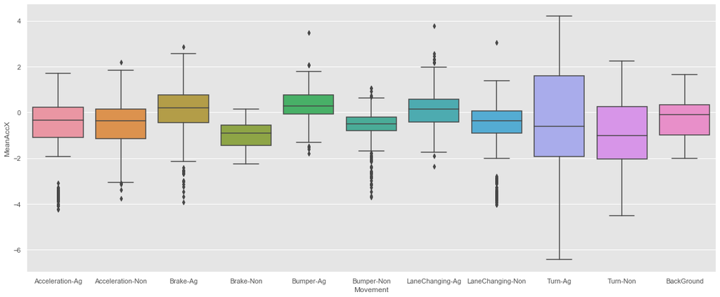

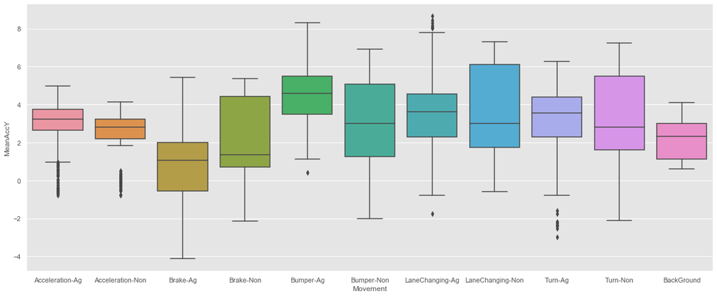

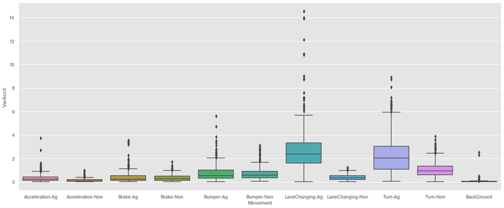

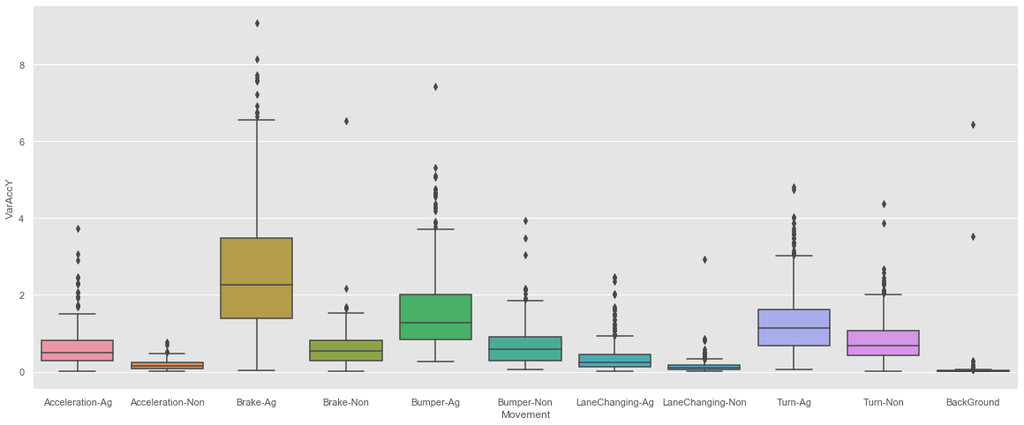

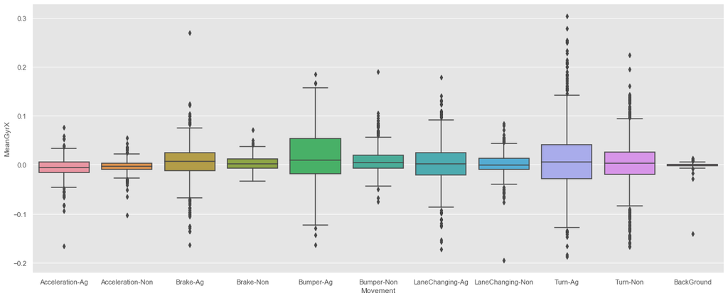

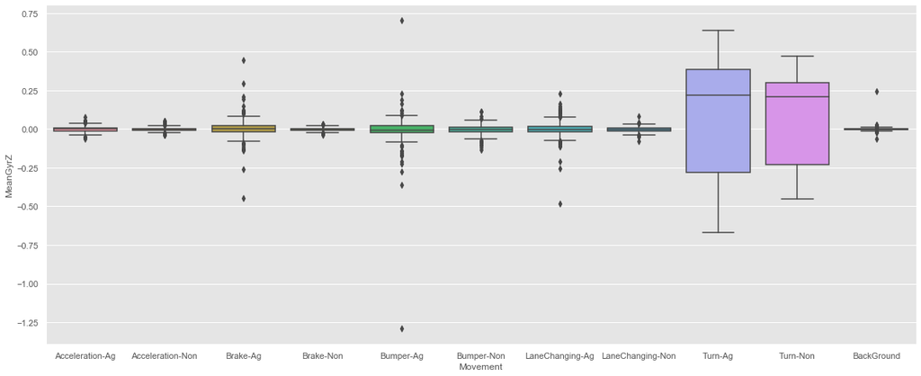

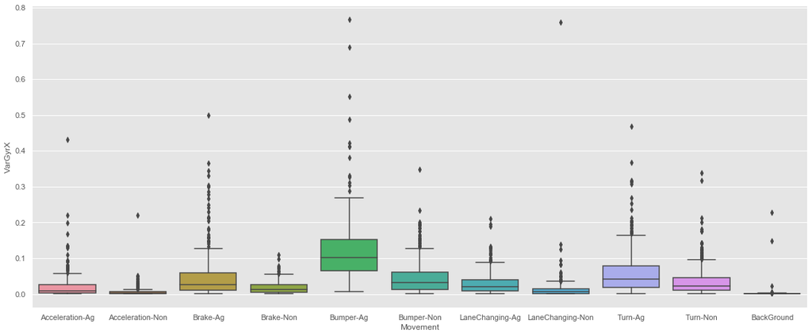

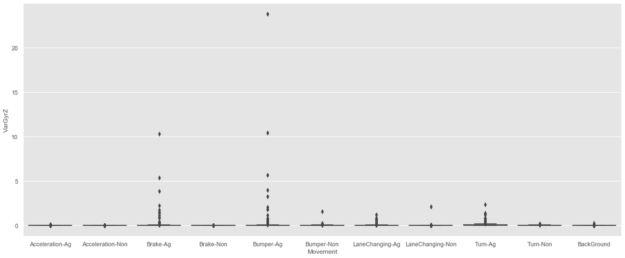

```python
column = ['MeanAccX', 'MeanAccY', 'VarAccX', 'VarAccY', 'MeanGyrX', 'MeanGyrZ', 'VarGyrX', 'VarGyrZ']
for col in column:
    plt.subplots(figsize=(20, 8))
    sns.boxplot(x="Movement", y=col, data=df)
```

Some interesting relationships that we discover from the above box plots are as follows:

The plot of MeanGyrzZ with the movements shows us some very important visualization. We can see that the value is close to zero for all other movements except for the turns. The range of MeanGyrZ for turns is quite high which would make sense as it is mostly a steering movement which would be detected by Gyroscope while all other movements are mostly to be detected by the accelerometer.